# DevEcon_Project1

Hoda Noorbakhsh

2024-11-24

According to the Statistical Center of Iran, the basic metals industry includes the production of basic iron and steel, essential copper and aluminum products, precious metals, and other primary products excluding iron, steel, copper, and aluminum, as well as iron and steel casting and non-ferrous metal casting. Given Iran’s substantial production volume in these categories and the industry’s significant share in the country’s total production, the basic metals industry was chosen for this project. Additionally, its high sensitivity to global trends and changes in the dollar exchange rate prompted an examination of its transformations over the past decade.

```r
#Read and clean data

file_path <- "F:/uni/master/3/Develop Economy/Project1/SeriZamani_Sanat_81-99.xlsx"

column_names <- c(
  "Year",
  "ActivityCodeLevel",
  "ActivityCode",
  "Activity",
  "NumWorkshops",
  "وضع مالکیت خصوصی تعاونی",
  "وضع مالکیت خصوصی سایر",
  "وضع مالکیت عمومی",
  "نحوه مدیریت خصوصی",
  "نحوه مدیریت عمومی",
  "TotNumEmployees",
  "MaleEmplo",
  "FemalEmplo",
  "Male_Wage_Emplo",
  "Female_Wage_Emplo",
  "Male_Not_Wage_Emplo",
  "Female_Not_Wage_Emplo",
  "Val_Compens_Services",
  "Total_Raw_Material_Val",
  "Foreign_Raw_Material_Val",
  "Production_Val",
  "Sales_Val",
  "Direct_Export_Val_Rial",
  "Direct_Export_Val_Dollars",
  "ارزش نهاده فعالیت صنعتی",
  "ارزش ستانده فعالیت صنعتی",
  "Added_Val_indus_Act",
  "ارزش خدمات غیرصنعتی دریافتی",
  "ارزش خدمات غیرصنعتی پرداختی",
  "Val_Indirect_Tax_Dut",
  "ارزش تشکیل سرمایه تغییرات انبار",
  "Fix_Cap_Val"
)
data <- read_excel(file_path, sheet = 2, skip = 4, col_names = FALSE)
colnames(data) <- column_names
```

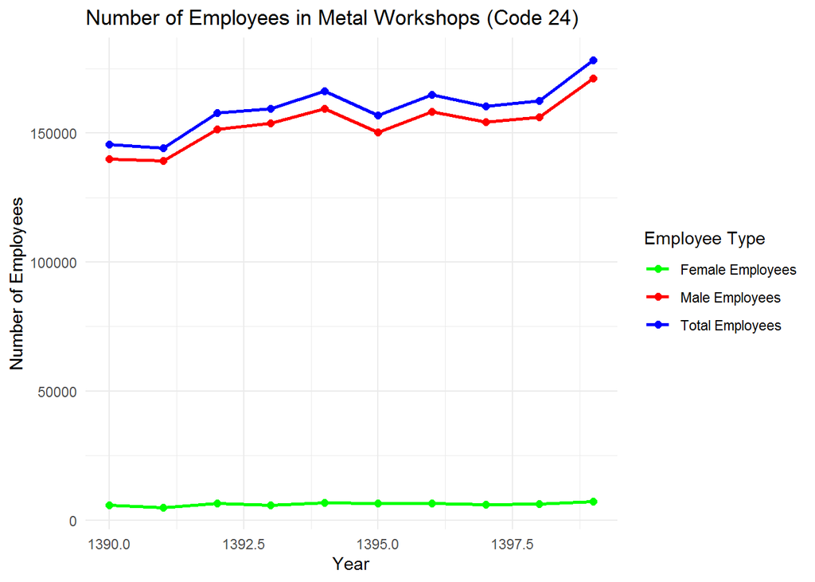

```r
filtered_data <- data[data$ActivityCode == 24 & data$Year >= 1390 & data$Year <= 1399, ]
total_data <- data[data$ActivityCodeLevel == 1 & data$Year >= 1390 & data$Year <= 1399, ]

filtered_data_2 <- data[data$ActivityCode == 24 & data$Year >= 1393 & data$Year <= 1399, ]
total_data_2 <- data[data$ActivityCodeLevel == 1 & data$Year >= 1393 & data$Year <= 1399, ]

long_data <- filtered_data %>%
  pivot_longer(
    cols = c(TotNumEmployees, MaleEmplo, FemalEmplo),
    names_to = "Type",
    values_to = "Employees"
  )

ggplot(long_data, aes(x = Year, y = Employees, color = Type)) +
  geom_line(size = 1) +
  geom_point(size = 2) +
  scale_color_manual(
    values = c("TotNumEmployees" = "blue", "MaleEmplo" = "red", "FemalEmplo" = "green"),
    labels = c("Female Employees", "Male Employees", "Total Employees")
  ) +
  labs(
    title = "Number of Employees in Metal Workshops (Code 24)",
    x = "Year",
    y = "Number of Employees",
    color = "Employee Type"
  ) +
  theme_minimal()
```

```r
ggsave("Employees_Metals.pdf")
```

```r
#Adding Iranian inflation data from the Central Bank of the IRI

inflation_data <- data.frame(
  Year = c(1390:1399),
  InflationRate = c(21.5, 30.5, 34.7, 15.6, 11.9, 9.0, 9.6, 31.2, 41.2, 47.1)
)
merged_data <- merge(filtered_data, inflation_data, by = "Year", all.x = TRUE)
total_merged_data <- merge(total_data, inflation_data, by = "Year", all.x = TRUE)
```

```r
#Adjusting price columns to 1390 rates

columns_to_adjust <- c("Production_Val", "Sales_Val", "Added_Val_indus_Act",
                       "Val_Indirect_Tax_Dut", "Fix_Cap_Val")

merged_data <- merged_data %>%
  mutate(Adjusted_Factor = 1)

for (i in 1:nrow(merged_data)) {
  if (merged_data$Year[i] > 1390) {
    inflation_factors <- 1 + merged_data$InflationRate[merged_data$Year >= 1390 & merged_data$Year < merged_data$Year[i]] / 100
    merged_data$Adjusted_Factor[i] <- prod(inflation_factors)
  }
}

merged_data <- merged_data %>%
  mutate(across(all_of(columns_to_adjust),
                ~ . / Adjusted_Factor,
                .names = "{.col}_adjusted"))


total_merged_data <- total_merged_data %>%
  mutate(Adjusted_Factor = 1)

for (i in 1:nrow(total_merged_data)) {
  if (total_merged_data$Year[i] > 1390) {
    inflation_factors <- 1 + total_merged_data$InflationRate[total_merged_data$Year >= 1390 & total_merged_data$Year < total_merged_data$Year[i]] / 100
    total_merged_data$Adjusted_Factor[i] <- prod(inflation_factors)
  }
}

total_merged_data <- total_merged_data %>%
  mutate(across(all_of(columns_to_adjust),
                ~ . / Adjusted_Factor,
                .names = "{.col}_adjusted"))
```

Several charts illustrate the alignment of this industry with the overall trends in Iran’s industrial sector. However, the same cannot be said for dollar-denominated exports. While both total exports and base metal industry exports followed a similar trend up to 2017, a divergence occurred after that. Following the U.S. withdrawal from the JCPOA (Joint Comprehensive Plan of Action) and the Iranian government’s implementation of a fixed exchange rate of 42,000 IRR/USD, total exports declined over the next two years, whereas exports in the base metals industry experienced an increase.